# 2. Regression and model validation

*Describe the work you have done this week and summarize your learning.*

- Describe your work and results clearly.
- Assume the reader has an introductory course level understanding of writing and reading R code as well as statistical methods.
- Assume the reader has no previous knowledge of your data or the more advanced methods you are using.

```
## [1] "Tue Nov 10 04:19:24 2020"
```

I’ve read and wrangled data from http://www.helsinki.fi/~kvehkala/JYTmooc/JYTOPKYS3-data.txt into an analysis dataset which I named as “learning2014”. The data was collected for the study of “The relationship between learning approaches and students’ achievements in an introductory statistics course in Finland” as outlined by Kimmo Vehkalahti in his presentation in ISI2015, the 60th World Statistics Congress. Presentation slides with more background info about the study and results are available [here](https://www.slideshare.net/kimmovehkalahti/the-relationship-between-learning-approaches-and-students-achievements-in-an-introductory-statistics-course-in-finland).

The analysis dataset “learning2014” contains 166 observations (rows) of 7 variables (columns).

A sample (first six observations) of the data:

```
##   gender age attitude     deep  stra     surf points
## 1      F  53       37 3.583333 3.375 2.583333     25
## 2      M  55       31 2.916667 2.750 3.166667     12
## 3      F  49       25 3.500000 3.625 2.250000     24
## 4      M  53       35 3.500000 3.125 2.250000     10
## 5      M  49       37 3.666667 3.625 2.833333     22
## 6      F  38       38 4.750000 3.625 2.416667     21
```

And a graphical overview of the data with summaries of the variables in the data:

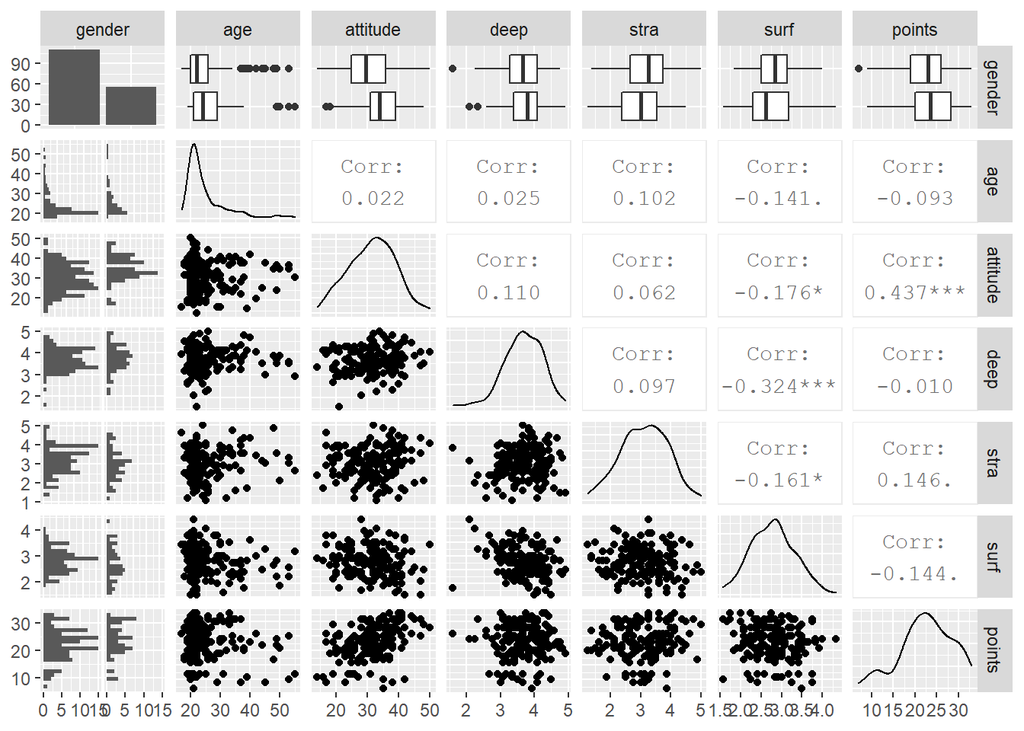

Next, I’ve created a regression model with `points` as the dependent variable and three variables having the highest absolute correlation with `points` as explanatory variables: `attitude`, `stra` and `surf`.

```
##
## Call:
## lm(formula = points ~ attitude + stra + surf, data = learn)
##
## Residuals:
##      Min       1Q   Median       3Q      Max
## -17.1550  -3.4346   0.5156   3.6401  10.8952
##
## Coefficients:
##             Estimate Std. Error t value Pr(>|t|)
## (Intercept) 11.01711    3.68375   2.991  0.00322 **
## attitude     0.33952    0.05741   5.913 1.93e-08 ***
## stra         0.85313    0.54159   1.575  0.11716
## surf        -0.58607    0.80138  -0.731  0.46563
## ---
## Signif. codes:  0 '***' 0.001 '**' 0.01 '*' 0.05 '.' 0.1 ' ' 1
##
## Residual standard error: 5.296 on 162 degrees of freedom
## Multiple R-squared:  0.2074, Adjusted R-squared:  0.1927
## F-statistic: 14.13 on 3 and 162 DF,  p-value: 3.156e-08
```

There’s a statistically significant relationship between`points`and the explanatory variable `attitude` but not between `points` and the other explanatory variables `stra` and `surf`.

The model can be simplified and fitted with `attitude` as the only explanatory variable as follows:

```
##
## Call:
## lm(formula = points ~ attitude, data = learn)
##
## Residuals:
##      Min       1Q   Median       3Q      Max
## -16.9763  -3.2119   0.4339   4.1534  10.6645
##
## Coefficients:
##             Estimate Std. Error t value Pr(>|t|)
## (Intercept) 11.63715    1.83035   6.358 1.95e-09 ***
## attitude     0.35255    0.05674   6.214 4.12e-09 ***
## ---
## Signif. codes:  0 '***' 0.001 '**' 0.01 '*' 0.05 '.' 0.1 ' ' 1
##
## Residual standard error: 5.32 on 164 degrees of freedom
## Multiple R-squared:  0.1906, Adjusted R-squared:  0.1856
## F-statistic: 38.61 on 1 and 164 DF,  p-value: 4.119e-09
```

In addition to a linear relationship between the dependent and independent variables, linear regression model assumes that the residuals are independent, have constant variance, and are normally distributed. Residuals are leftover of the dependent variable after fitting a model (independent variables) to data and they could reveal unexplained patterns in the data by the fitted model. Patterns in residuals can be explored with diagnostic plots.

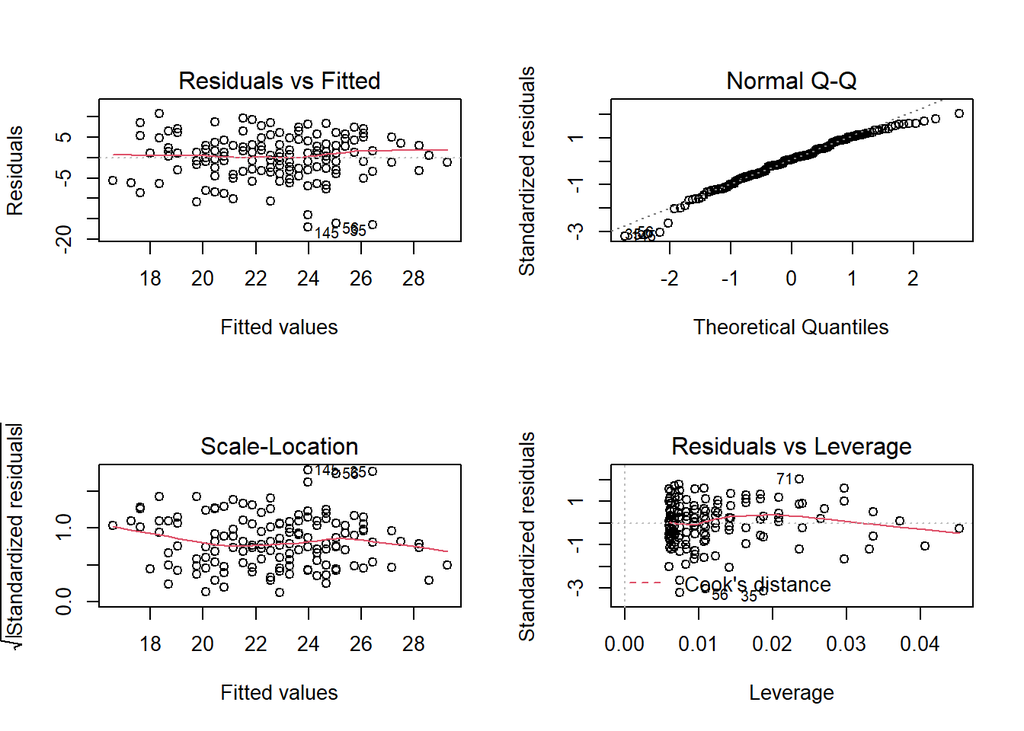

```r
# create a regression model
mymod <- lm(points ~ attitude, data = learn)

# draw diagnostic plots using the plot() function
par(mfrow = c(2,2))
plot(mymod)
```

```r
# Note: intentional deviation from exercise instructions
# To produce plots 1, 2 and 5 only, use argument which = c(1,2,5)
```

**Residuals vs Fitted** plot shows if residuals have non-linear patterns. Here, cases are distributed quite equally around the horizontal line and no obvious pattern can be detected.

**Normal Q-Q** plot helps to assess whether residuals are normally distributed. Here, the points appear to skew away from the straight line especially at the lower tail meaning that residuals are not normally distributed. Cases #145, #35 and #56 should be explored further as they have standardized residuals below -3.

**Scale-Location** plot can be used to check the assumption of constant variance. Here, the residuals appear randomly spread along a horizontal line confirming the assumption.

**Residuals vs Leverage** plot helps to identify influential cases in the data. Here, Cook’s distance lines (red dashed lines) are not even visible, meaning that all cases are well within Cook’s distance and not influential to the regression results.